# Introduction to R with tidyverse

10/28/2019

## Previosly on “Intro to CDA with R”

## Introduction to the course

We…

- … discussed what is a categorical variable
- … saw a few examples of survey questions that collect categorical information (and today we will analyze that data)
- … fixed some administrative stuff

Hopefully now you all read chapters 1 and 2 of the “R for Data Science” and today we will move on to the next steps

## Some admin. stuff

- Students can earn 5 credit points (instead of Hausarbeit of 20-25 pages for 10 credits; whomever wishes to get only 5 can simply write an essay of 10-15 pages with an analysis of categorical data)
- No lecture on the 18.11.2019 (conference in Venice)
- Proposal: start at 10:00 a.m. instead of 10:15
- Material is now also on [Github](https://github.com/xlejx-rodsxn/CDA-in-R---HU) or type in “[https://github.com/xlejx-rodsxn/CDA-in-R—HU](https://github.com/xlejx-rodsxn/CDA-in-R---HU)”

## Now, Quizz No. 1

On to the [Quiz No. 1](https://docs.google.com/forms/d/e/1FAIpQLSfHkVka3ONvyG_k9BbLlHAo8OVOjyGGvNDagJMYUUBoeiEAWw/viewform?usp=sf_link)

- You have five minutes to complete it

## R with tidyverse

## Workflow

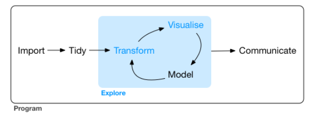

- Import data
- Tidy data
- Wrangle data
- Describe data
- Visualize data

## Basic R Studio functionality

- Check out the [cheat sheets!](https://rstudio.com/resources/cheatsheets/)
- We will look at base R and data transformation cheat sheets for today

## Getting your data into R

- Data comes in many formats (e.g. .xlsx, .sav, .dat, .csv, .RDS)
- To read it, we use packages!

But what are packages?

“Packages are the fundamental units of reproducible R code. They include reusable functions, the documentation that describes how to use them, and sample data.”

BTW: Anyone can write their own package in R!

## Tidy your data and transform it

- Check out the cheat sheets

## Analyze data

- We will consider a few basic R functions

## PISA

## Let’s write our own mini-report on Rmarkdown

- Introduction to Rmarkdown
- PISA data [download](https://www.oecd.org/pisa/data/2015database/)